# Introduction

In this project, you will build a neural network of your own design to evaluate the MNIST dataset.

Some of the benchmark results on MNIST include can be found [on Yann LeCun's page](https://webcache.googleusercontent.com/search?q=cache:stAVPik6onEJ:yann.lecun.com/exdb/mnist) and include:

88% [Lecun et al., 1998](https://hal.science/hal-03926082/document)

95.3% [Lecun et al., 1998](https://hal.science/hal-03926082v1/document)

99.65% [Ciresan et al., 2011](http://people.idsia.ch/~juergen/ijcai2011.pdf)

MNIST is a great dataset for sanity checking your models, since the accuracy levels achieved by large convolutional neural networks and small linear models are both quite high. This makes it important to be familiar with the data.

## Installation

```python
# Update the PATH to include the user installation directory.
import os
os.environ['PATH'] = f"{os.environ['PATH']}:/root/.local/bin"
os.environ['PATH'] = f"{os.environ['PATH']}:/opt/conda/lib/python3.7/site-packages"
# Restart the Kernel before you move on to the next step.
```

```python
# Do not execute the commands below unless you have restart the Kernel after updating the PATH.
# !python -m pip install torch==1.0.0
```

```python
# Check torch version and CUDA status if GPU is enabled.
import torch
print(torch.__version__)
print(torch.cuda.is_available()) # Should return True when GPU is enabled.
```

```
1.11.0+cu102
True
```

#### Important: Restart the Kernel before you move on to the next step.

```python
# Install requirements
!python -m pip install -r requirements.txt
```

## Imports

```python
## This cell contains the essential imports you will need – DO NOT CHANGE THE CONTENTS! ##
import numpy as np
import matplotlib.pyplot as plt

import torch
import torch.nn as nn
import torch.nn.functional as F
import torch.optim as optim
import torchvision
import torchvision.transforms as transforms
from torchvision import datasets, transforms, models
```

```python
## Import additional library
from PIL import Image

# Config image display criteria
%matplotlib inline
%config InlineBackend.figure_format = 'retina'

# To save training and test scores and plot the training and validation loss values
import pandas as pd
import matplotlib.pyplot as plt
```

## Load the Dataset

MNIST is fortunately included in the torchvision module. Then, you can create your dataset using the `MNIST` object from `torchvision.datasets` ([the documentation is available here](https://pytorch.org/vision/stable/datasets.html#mnist)). Make sure to specify `download=True`!

Once your dataset is created, you'll also need to define a `DataLoader` from the `torch.utils.data` module for both the train and the test set.

```python
# Define transforms
## YOUR CODE HERE ##

# data_root_dir = './data'
# norm_mean = [0.485, 0.456, 0.406]
# norm_std = [0.229, 0.224, 0.225]
# img_scale = 255
# img_crop = 244
# batch_size = 32

# train_transforms = transforms.Compose([
#     transforms.ToTensor(),
#     transforms.Resize(img_scale),
#     transforms.RandomRotation(30),
#     transforms.RandomResizedCrop(img_crop),
#     transforms.RandomHorizontalFlip(),
#     transforms.RandomAffine(scale=(0.9, 1.1), translate=(0.1, 0.1), degrees=10, fill=0, interpolation=transforms.InterpolationMode.BILINEAR)
#     transforms.Normalize(norm_mean, norm_std),
# ])
# test_transforms = transforms.Compose([
#     transforms.ToTensor(),
#     transforms.Resize(img_scale),
#     transforms.CenterCrop(img_crop),
#     transforms.Normalize(norm_mean, norm_std),
# ])



data_root_dir = './data'
norm_mean = [0.5]
norm_std = [0.5]
img_scale = 28
scale = [0.9, 1.1]
translate = [0.1, 0.1]
rotate = 10
batch_size = 128 #128, 64, 32
flip = 0.1

# train_transforms = transforms.Compose([
#     transforms.ToTensor(),
# #     transforms.Resize(img_scale),
# #     transforms.RandomRotation(rotate),
# #     transforms.RandomHorizontalFlip(flip),
#     transforms.RandomAffine(scale=scale, translate=translate, degrees=rotate, fill=0, interpolation=transforms.InterpolationMode.BILINEAR),
#     transforms.Normalize(norm_mean, norm_std),
# ])
# test_transforms = transforms.Compose([
#     transforms.ToTensor(),
# #     transforms.Resize(img_scale),
#     transforms.Normalize(norm_mean, norm_std),
# ])

data_transforms = transforms.Compose([
    transforms.ToTensor(),
    transforms.Normalize(norm_mean, norm_std),
])
```

```python
# Create training set and define training dataloader
## YOUR CODE HERE ##

## Load training data
# training_data = datasets.MNIST(root=data_root_dir, train=True, download=True, transform=train_transforms)
training_data = datasets.MNIST(root=data_root_dir, train=True, download=True, transform=data_transforms)
print(training_data)

## Create training data loader
training_loader = torch.utils.data.DataLoader(training_data, batch_size=batch_size, shuffle=True)
print(training_loader)

## Randomly split training data into training and validation data
## The model will be trained on the entire training set but to see the model's improvement
## we are splitting some data to subset to make a temporary validation data
train_data, val_data = torch.utils.data.random_split(training_data, [50000, 10000])

print('=====>', type(training_data), type(train_data))

## Create temporary training and validation data loader
train_loader = torch.utils.data.DataLoader(train_data, batch_size=batch_size, shuffle=True)
print(train_loader)

val_loader = torch.utils.data.DataLoader(val_data, batch_size=batch_size, shuffle=True)
val_loader
```

```
Dataset MNIST
    Number of datapoints: 60000
    Root location: ./data
    Split: Train
    StandardTransform
Transform: Compose(
               ToTensor()
               Normalize(mean=[0.5], std=[0.5])
           )
<torch.utils.data.dataloader.DataLoader object at 0x7ea109256110>
=====> <class 'torchvision.datasets.mnist.MNIST'> <class 'torch.utils.data.dataset.Subset'>
<torch.utils.data.dataloader.DataLoader object at 0x7ea11e07c410>
```

```
<torch.utils.data.dataloader.DataLoader at 0x7ea105a51a90>
```

```python
# Create test set and define test dataloader
## YOUR CODE HERE ##

## Loading test data
# test_data = datasets.MNIST(root=data_root_dir, train=False, download=True, transform=test_transforms)
test_data = datasets.MNIST(root=data_root_dir, train=False, download=True, transform=data_transforms)
print(test_data)

## Create temporary test data loader
test_loader = torch.utils.data.DataLoader(test_data, batch_size=batch_size)
test_loader
```

```
Dataset MNIST
    Number of datapoints: 10000
    Root location: ./data
    Split: Test
    StandardTransform
Transform: Compose(
               ToTensor()
               Normalize(mean=[0.5], std=[0.5])
           )
```

```
<torch.utils.data.dataloader.DataLoader at 0x7ea105a47850>
```

##### Data exploration and do some preprocessing to make proper data subset out of main data

```python
training_data.targets.unique(), test_data.targets.unique()
```

```
(tensor([0, 1, 2, 3, 4, 5, 6, 7, 8, 9]),
 tensor([0, 1, 2, 3, 4, 5, 6, 7, 8, 9]))
```

```python
dataiter = iter(test_loader)
batch = next(dataiter)
len(batch), len(batch[1]), batch[1].unique()
```

```
(2, 128, tensor([0, 1, 2, 3, 4, 5, 6, 7, 8, 9]))
```

```python
train_data.dataset.data[train_data.indices].shape, val_data.dataset.data[val_data.indices].shape
```

```
(torch.Size([50000, 28, 28]), torch.Size([10000, 28, 28]))
```

```python
train_data.data = train_data.dataset.data[train_data.indices]
train_data.targets = train_data.dataset.targets[train_data.indices]

val_data.data = val_data.dataset.data[val_data.indices]
val_data.targets = val_data.dataset.targets[val_data.indices]
```

```python
training_data.data.shape, test_data.data.shape
```

```
(torch.Size([60000, 28, 28]), torch.Size([10000, 28, 28]))
```

```python
train_data.data.shape, val_data.data.shape
```

```
(torch.Size([50000, 28, 28]), torch.Size([10000, 28, 28]))
```

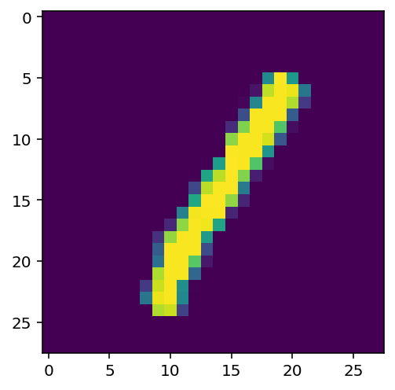

```python
i = 0
indx = i
plt.imshow(train_data.data[indx]);
```

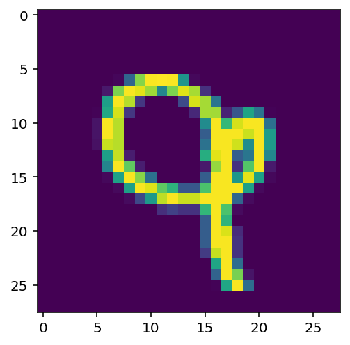

```python
indx = i
plt.imshow(val_data.data[indx]);
```

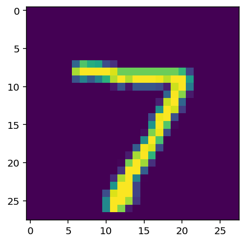

```python
indx = i
plt.imshow(test_data.data[indx]);
```

## Justify your preprocessing

In your own words, why did you choose the transforms you chose? If you didn't use any preprocessing steps, why not?

**DOUBLE CLICK THIS CELL TO MODIFY**

## Explore the Dataset

Using matplotlib, numpy, and torch, explore the dimensions of your data.

You can view images using the `show5` function defined below – it takes a data loader as an argument. Remember that normalized images will look really weird to you! You may want to try changing your transforms to view images. Typically using no transforms other than `toTensor()` works well for viewing – but not as well for training your network. If `show5` doesn't work, go back and check your code for creating your data loaders and your training/test sets.

```python
## This cell contains a function for showing 5 images from a dataloader – DO NOT CHANGE THE CONTENTS! ##
def show5(img_loader):
    dataiter = iter(img_loader)

    batch = next(dataiter)
    labels = batch[1][0:5]
    images = batch[0][0:5]
    for i in range(5):
        print(int(labels[i].detach()))

        image = images[i].numpy()
        plt.imshow(image.T.squeeze().T)
        plt.show()
```

```
4
```

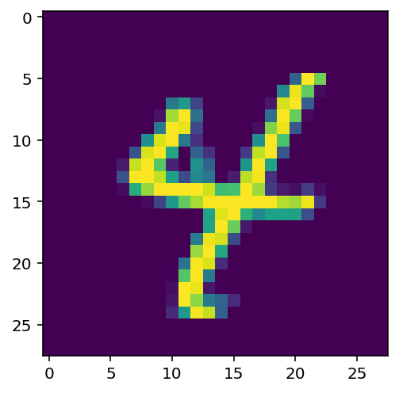

```
7
```

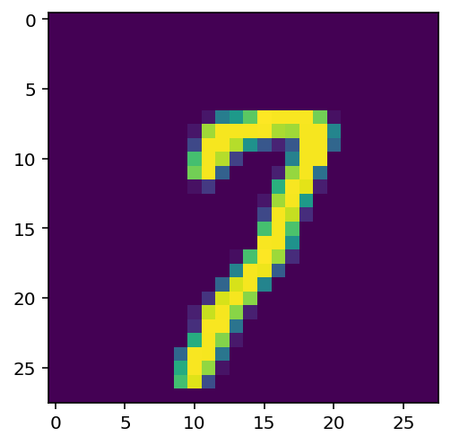

```
9
```

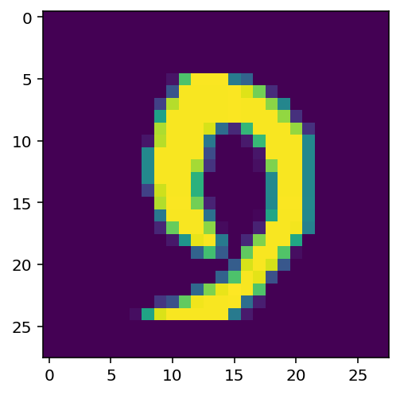

```
7
```

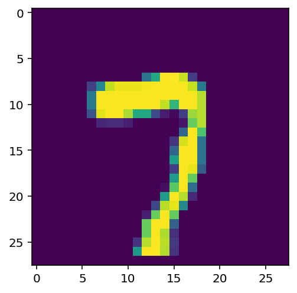

```
6
```

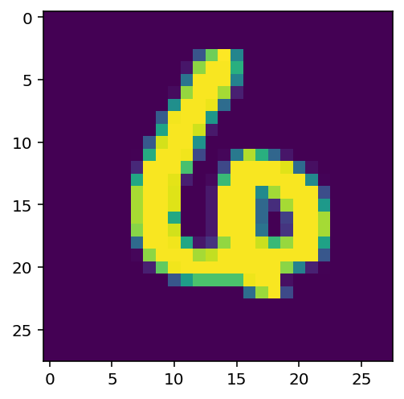

```python
# Explore data
## YOUR CODE HERE ##

show5(training_loader)
```

```
7
```

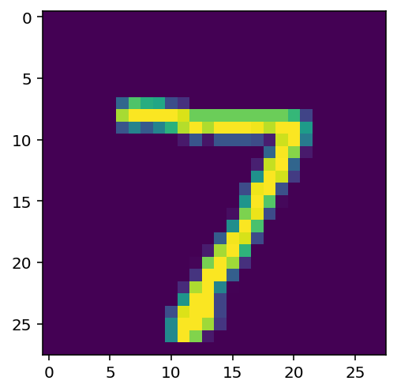

```
2
```

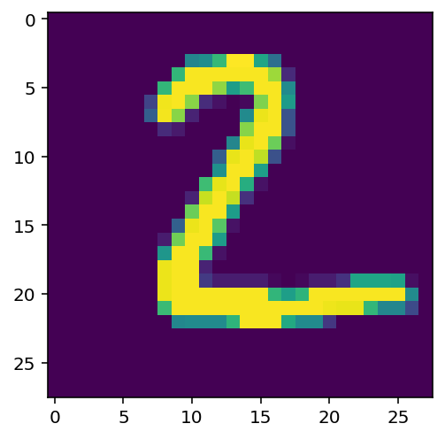

```
1
```

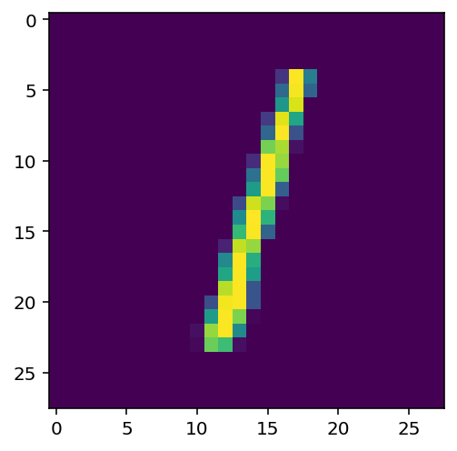

```
0
```

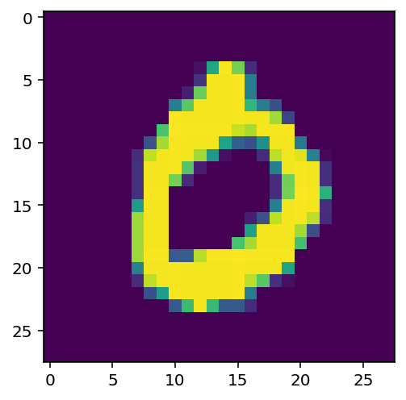

```
4
```

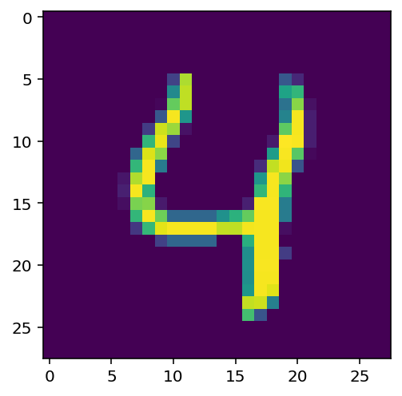

```python
show5(test_loader)
```

## Build your Neural Network

Using the layers in `torch.nn` (which has been imported as `nn`) and the `torch.nn.functional` module (imported as `F`), construct a neural network based on the parameters of the dataset. Use any architecture you like.

*Note*: If you did not flatten your tensors in your transforms or as part of your preprocessing and you are using only `Linear` layers, make sure to use the `Flatten` layer in your network!

```python
## YOUR CODE HERE ##

class Proj2NN(nn.Module):
    def __init__(self, input_size, hidden_size, num_classes, criterion):
        super().__init__()
        self.criterion = criterion
        self.all_layers =  nn.ModuleList()

        flatten = nn.Flatten()
        self.all_layers.append(flatten)

        input_layer = nn.Linear(input_size, hidden_size[0])
        self.all_layers.append(input_layer)

        for i in range(len(hidden_size)-1):
            hidden_layer = nn.Linear(hidden_size[i], hidden_size[i+1])
            self.all_layers.append(hidden_layer)

        output_layer = nn.Linear(hidden_size[-1], num_classes)
        self.all_layers.append(output_layer)
        if self.criterion.__class__==torch.nn.modules.loss.NLLLoss:
            self.softmax_layer = nn.LogSoftmax(dim=1)

#         print(f'Total layers: {len(self.all_layers)}')


    def forward(self, x):
        i = 2
        x = self.all_layers[0](x)
        for layer in self.all_layers[1:-1]:
            x = layer(x)
            x = F.relu(x)
            i += 1
        x = self.all_layers[-1](x)
        if self.criterion.__class__==torch.nn.modules.loss.NLLLoss:
#             x = F.log_softmax(x, dim=1)
            x = self.softmax_layer(x)
        return x


def create_model(model_type, input_size, num_classes, criterion):
    # Create model
    model = None
    if model_type==0:
        model = Proj2NN(input_size, [128, 64], num_classes, criterion, criterion)
    elif model_type==1:
        model = Proj2NN(input_size, [256, 128], num_classes, criterion)
    elif model_type==2:
        model = Proj2NN(input_size, [512, 64], num_classes, criterion)
    elif model_type==3:
        model = Proj2NN(input_size, [128, 64, 32], num_classes, criterion)
    elif model_type==4:
        model = Proj2NN(input_size, [256, 128, 64], num_classes, criterion)
    elif model_type==5:
        model = Proj2NN(input_size, [256, 128, 64, 32], num_classes, criterion)
    elif model_type==6:
        model = Proj2NN(input_size, [512, 256, 128], num_classes, criterion)
    elif model_type==7:
        model = Proj2NN(input_size, [512, 256, 128, 64, 32], num_classes, criterion)
    elif model_type==8:
        model = Proj2NN(input_size, [1024, 512, 256], num_classes, criterion)
    elif model_type==9:
        model = Proj2NN(input_size, [1024, 512, 256, 128], num_classes, criterion)
    else:
        model = Proj2NN(input_size, [128], num_classes, criterion)
    return model
```

```python
# A function defined for - Training the model
def train_model(model, trainloader, validationloader, criterion, optimizer, epochs=5, print_every=20, device='cuda'):
    # Initialise the common variables used in the training process
    train_loss_rec = []
    val_loss_rec = []
    val_acc_rec = []

    steps = 0
    running_loss = 0

    # start = time.time()
    for epoch in range(epochs):
    #     ep_start = time.time()
        for pass_count, (inputs, labels) in enumerate(trainloader):
    #         bt_start = time.time()
            steps += 1
            # Move input and label tensors to the default device
            inputs, labels = inputs.to(device), labels.to(device)
#             print(f'Train: epoch:{epoch}, pass_count:{pass_count}, labels len:{len(labels)}')

            outputs = model(inputs)
#             print(labels.unique(), outputs.unique())
            loss = criterion(outputs, labels)

            optimizer.zero_grad()
            loss.backward()
            optimizer.step()

            running_loss += loss.item()


            # Model validation after n batches
            if steps % print_every == 0:
                validation_loss = 0
                accuracy = 0
                model.eval()
                with torch.no_grad():
                    for test_pass_count, (test_inputs, test_labels) in enumerate(validationloader):
                        test_inputs, test_labels = test_inputs.to(device), test_labels.to(device)
#                         print(f'Val: epoch:{epoch}, test_pass_count:{test_pass_count}, labels len:{len(test_labels)}')
                        test_outputs = model(test_inputs)
                        batch_loss = criterion(test_outputs, test_labels)

                        validation_loss += batch_loss.item()

                        ## Calculate accuracy
                        ps = torch.exp(test_outputs)
                        top_p, top_class = ps.topk(1, dim=1)
                        equals = top_class == test_labels.view(*top_class.shape)
                        accuracy += torch.mean(equals.type(torch.FloatTensor)).item()

#                         _, predicted = torch.max(outputs.data, 1)
#                         total += labels.size(0)
#                         correct += (predicted == labels).sum().item()

                print(f"Epoch {epoch+1}/{epochs}.. "
                      f"Train loss: {running_loss/print_every:.4f}.. "
                      f"Validation loss: {validation_loss/len(validationloader):.4f}.. "
                      f"Validation accuracy: {(accuracy/len(validationloader))*100:.2f}")

                train_loss_rec.append(running_loss/print_every)
                val_loss_rec.append(validation_loss/len(validationloader))
                val_acc_rec.append((accuracy/len(validationloader))*100)
                running_loss = 0
                model.train()
#                 save_model(model, model_type, model_name, num_output, criterion, optimizer, train_data)

    #         print(f"Total batch time: {(time.time() - bt_start):.3f} seconds\n")
    #     print(f"Total epoch time: {(time.time() - ep_start):.3f} seconds")
    # print(f"Total training time: {(time.time() - start):.3f} seconds")
    return train_loss_rec, val_loss_rec, val_acc_rec
```

Specify a loss function and an optimizer, and instantiate the model.

If you use a less common loss function, please note why you chose that loss function in a comment.

**Anser:** I choose CrossEntropyLoss, however the NLLLoss could be used. NLLLoss need the softmax to employ manually where the CrossEntropyLoss automatically does that. And both of these loss functions provide the probability scores for a prediction associated to each of the label.

```python
## YOUR CODE HERE ##

# Hyperparameters - Set up variables for training and testing criteria
input_size = img_scale * img_scale
hidden_size = [128]
num_classes = len(training_data.targets.unique()) #10
num_epochs = 2 #20, 10, 5, 2
print_every = 5 #20
learning_rate = 0.001
# ##batch_size = 32


# Loss function
# criterion = nn.NLLLoss()
criterion = nn.CrossEntropyLoss() ##- it will implement the softmax automatically

exp_group = 0 #10**2
model_type = 1 #2 hidden layer with 256, and 128 nodes
model = create_model(model_type, input_size, num_classes, criterion)

# Optimizer - adam optimiser
optimizer = optim.Adam(model.parameters(), lr=learning_rate)
# optimizer = optim.SGD(model.parameters(), lr=learning_rate)
# optimizer = optim.Adamax(model.parameters(), lr=learning_rate)



# Use GPU if it's available
device = torch.device("cuda" if torch.cuda.is_available() else "cpu")
print(device)

# Move the model to appropriate device
model.to(device)


# Model summary
print(model)
print(list(model.parameters()))
```

[output not shown]

[output cut: 32 more lines]

[output not shown]

```python
%whos
```

```
Variable          Type                            Data/Info
-----------------------------------------------------------
F                 module                          <module 'torch.nn.functio<...>/torch/nn/functional.py'>
Image             module                          <module 'PIL.Image' from <...>e-packages/PIL/Image.py'>
Proj2NN           type                            <class '__main__.Proj2NN'>
batch             list                            n=2
batch_size        int                             128
create_model      function                        <function create_model at 0x7ea0c811bb90>
criterion         CrossEntropyLoss                CrossEntropyLoss()
data_root_dir     str                             ./data
data_transforms   Compose                         Compose(\n    ToTensor()\<...>mean=[0.5], std=[0.5])\n)
dataiter          _SingleProcessDataLoaderIter    <torch.utils.data.dataloa<...>object at 0x7ea105ebff90>
datasets          module                          <module 'torchvision.data<...>on/datasets/__init__.py'>
device            device                          cuda
exp_group         int                             0
flip              float                           0.1
hidden_size       list                            n=1
i                 int                             0
img_numpy         ndarray                         28x28: 784 elems, type `uint8`, 784 bytes
img_scale         int                             28
indx              int                             0
input_size        int                             784
learning_rate     float                           0.001
model             Proj2NN                         Proj2NN(\n  (criterion): <...>es=10, bias=True)\n  )\n)
model_type        int                             1
models            module                          <module 'torchvision.mode<...>sion/models/__init__.py'>
nn                module                          <module 'torch.nn' from '<...>es/torch/nn/__init__.py'>
norm_mean         list                            n=1
norm_std          list                            n=1
np                module                          <module 'numpy' from '/op<...>kages/numpy/__init__.py'>
num_classes       int                             10
num_epochs        int                             2
optim             module                          <module 'torch.optim' fro<...>torch/optim/__init__.py'>
optimizer         Adam                            Adam (\nParameter Group 0<...>e\n    weight_decay: 0\n)
os                module                          <module 'os' from '/opt/c<...>nda/lib/python3.7/os.py'>
pd                module                          <module 'pandas' from '/r<...>ages/pandas/__init__.py'>
plt               module                          <module 'matplotlib.pyplo<...>es/matplotlib/pyplot.py'>
print_every       int                             5
rotate            int                             10
scale             list                            n=2
show5             function                        <function show5 at 0x7ea0c9e94b00>
test_data         MNIST                           Dataset MNIST\n    Number<...> std=[0.5])\n           )
test_loader       DataLoader                      <torch.utils.data.dataloa<...>object at 0x7ea105a47850>
torch             module                          <module 'torch' from '/op<...>kages/torch/__init__.py'>
torchvision       module                          <module 'torchvision' fro<...>torchvision/__init__.py'>
train_data        Subset                          <torch.utils.data.dataset<...>object at 0x7ea105a51950>
train_loader      DataLoader                      <torch.utils.data.dataloa<...>object at 0x7ea11e07c410>
train_model       function                        <function train_model at 0x7ea0c9be4440>
training_data     MNIST                           Dataset MNIST\n    Number<...> std=[0.5])\n           )
training_loader   DataLoader                      <torch.utils.data.dataloa<...>object at 0x7ea109256110>
transforms        module                          <module 'torchvision.tran<...>/transforms/__init__.py'>
translate         list                            n=2
val_data          Subset                          <torch.utils.data.dataset<...>object at 0x7ea105a51b10>
val_loader        DataLoader                      <torch.utils.data.dataloa<...>object at 0x7ea105a51a90>
view_in_detail    function                        <function view_in_detail at 0x7ea105ab5b00>
```

```python
str(data_transforms.__dict__), str(criterion.__dict__), str(optimizer.__dict__)
```

[output not shown]

```python
# variables_dict = {key: value for key, value in globals().items() if not key.startswith("__") and
#                   not callable(value) and isinstance(value, (int, float, str, list, tuple))}
# variables_dict = {key: value for key, value in globals().items() if not key.startswith("__") and
#                   not callable(value) and isinstance(value, (int, float, list, tuple)) and
#                   ket in ('')}
list_of_vars = ['data_root_dir', 'norm_mean', 'norm_std', 'img_scale', 'scale', 'translate', 'rotate', 'batch_size', 'flip',
                'input_size', 'hidden_size', 'num_classes', 'num_epochs', 'print_every', 'learning_rate']
variables_dict = {key: value for key, value in globals().items() if not key.startswith("__") and
                  not callable(value) and isinstance(value, (int, float, list, tuple)) and
                  key in list_of_vars}
variables_dict
```

```
{'norm_mean': [0.5],
 'norm_std': [0.5],
 'img_scale': 28,
 'scale': [0.9, 1.1],
 'translate': [0.1, 0.1],
 'rotate': 10,
 'batch_size': 128,
 'flip': 0.1,
 'input_size': 784,
 'hidden_size': [128],
 'num_classes': 10,
 'num_epochs': 2,
 'print_every': 5,
 'learning_rate': 0.001}
```

```python
all_exp_settings = pd.DataFrame({'variables':variables_dict.keys(), 'values':variables_dict.values()})
all_exp_settings
```

|  | variables | values |
| --- | --- | --- |
| 0 | norm_mean | [0.5] |
| 1 | norm_std | [0.5] |
| 2 | img_scale | 28 |
| 3 | scale | [0.9, 1.1] |
| 4 | translate | [0.1, 0.1] |
| 5 | rotate | 10 |
| 6 | batch_size | 128 |
| 7 | flip | 0.1 |
| 8 | input_size | 784 |
| 9 | hidden_size | [128] |
| 10 | num_classes | 10 |
| 11 | num_epochs | 2 |
| 12 | print_every | 5 |
| 13 | learning_rate | 0.001 |

```python
all_exp_settings.to_csv(f'all_exp_settings_{exp_group+model_type}.csv', index=False)
```

## Running your Neural Network

Use whatever method you like to train your neural network, and ensure you record the average loss at each epoch. Don't forget to use `torch.device()` and the `.to()` method for both your model and your data if you are using GPU!

If you want to print your loss **during** each epoch, you can use the `enumerate` function and print the loss after a set number of batches. 250 batches works well for most people!

```python
## YOUR CODE HERE ##

## Do training
# train_loss_rec, val_loss_rec, val_acc_rec = train_model(model, train_loader, val_loader, criterion, optimizer, epochs=num_epochs, print_every=print_every, device=device)
train_loss_rec, val_loss_rec, val_acc_rec = train_model(model, training_loader, val_loader, criterion, optimizer, epochs=num_epochs, print_every=print_every, device=device)
```

```python
'Save name', exp_group+model_type
```

```
('Save name', 1)
```

```python
train_loss_rec, val_loss_rec, val_acc_rec
train_scors = pd.DataFrame({'Training Loss':train_loss_rec, 'Validation Loss':val_loss_rec, 'Validation Accuracy':val_acc_rec})
train_scors
```

|  | Training Loss | Validation Loss | Validation Accuracy |
| --- | --- | --- | --- |
| 0 | 2.221137 | 2.044675 | 44.709256 |
| 1 | 1.897800 | 1.679036 | 59.849684 |
| 2 | 1.553169 | 1.308161 | 71.766218 |
| 3 | 1.211001 | 1.065661 | 64.725079 |
| 4 | 1.000696 | 0.867111 | 75.474684 |
| ... | ... | ... | ... |
| 182 | 0.167132 | 0.141341 | 95.856408 |
| 183 | 0.147541 | 0.153356 | 95.549842 |
| 184 | 0.140388 | 0.144854 | 95.678402 |
| 185 | 0.179103 | 0.131120 | 96.182753 |
| 186 | 0.184897 | 0.148320 | 95.569620 |

187 rows × 3 columns

```python
train_scors.to_csv(f'train_scors_{exp_group+model_type}.csv', index=False)
```

Plot the training loss (and validation loss/accuracy, if recorded).

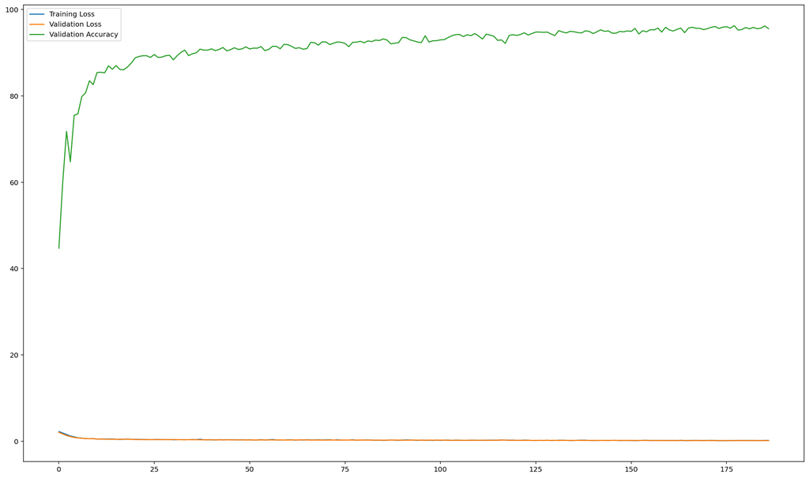

```python
## YOUR CODE HERE ##
# train_loss_rec, val_loss_rec, val_acc_rec
plot = train_scors.plot.line(figsize=(20,12))
fig = plot.get_figure()
fig.savefig(f'train_scors_{exp_group+model_type}.png')
```

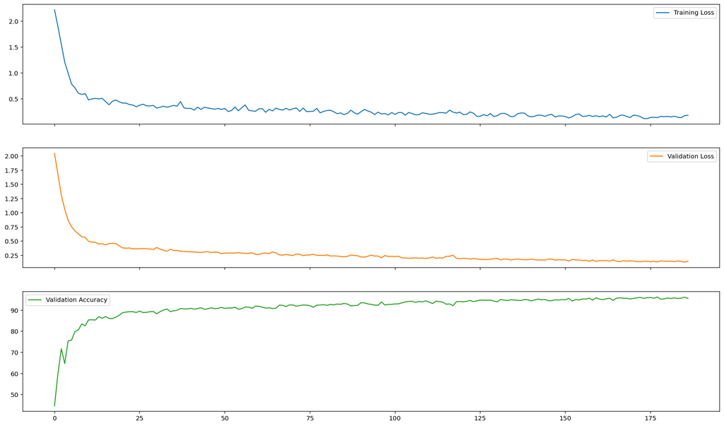

```python
plot = train_scors.plot.line(figsize=(20,12), subplots=True)
# fig = plot.get_figure()
plt.savefig(f'train_scors_subPlt_{exp_group+model_type}.png')
```

## Testing your model

Using the previously created `DataLoader` for the test set, compute the percentage of correct predictions using the highest probability prediction.

If your accuracy is over 90%, great work, but see if you can push a bit further! If your accuracy is under 90%, you'll need to make improvements. Go back and check your model architecture, loss function, and optimizer to make sure they're appropriate for an image classification task.

```python
## YOUR CODE HERE ##
# Testing the model
model.eval()
with torch.no_grad():
    correct = 0
    total = 0
    for images, labels in test_loader:
        images = images.view(-1, 28*28)
        # Move input and label tensors to the default device
        images, labels = images.to(device), labels.to(device)
        outputs = model(images)
        _, predicted = torch.max(outputs.data, 1)
        total += labels.size(0)
        correct += (predicted == labels).sum().item()

    print(f'Accuracy of the model on the 10000 test images: {100 * correct / total:.2f}%')
    test_scors = pd.DataFrame({'Test Acc':[correct / total]})
```

```
Accuracy of the model on the 10000 test images: 95.61%
```

```python
test_scors
```

|  | Test Acc |
| --- | --- |
| 0 | 0.9561 |

```python
test_scors.to_csv(f'test_scors{exp_group+model_type}_.csv', index=False)
```